# bayesian-mcmc-nb

Bayesian Inference · Portfolio Notebook

Bayesian Parameter Estimation with a Metropolis-Hastings MCMC Sampler

This notebook implements a Metropolis-Hastings sampler from first principles to estimate posterior distributions and runs prior-sensitivity analysis to show how prior choice affects the credible interval.

**Author:** Oscar D. Nava Quintero · [caelusbellum.github.io](https://caelusbellum.github.io/)  
**Course:** AD616 — Enterprise Risk Analytics, Boston University Metropolitan College  
**Program:** MS in Applied Business Analytics  
**Source:** AD616 Assignment 5 · original coursework; datasets and problem statements are anonymized or synthetic  
**Language / stack:** Python (NumPy, SciPy, pandas, Matplotlib), Jupyter

Shared as a portfolio artifact. Not intended for reuse as academic submission. © Oscar D. Nava Quintero.

# AD616 Assignment 5

**Oscar Quintero**

Date: June 8th, 2026

# Question 1

A real estate speculator is considering buying property at a resort island for $400 thousand. The local government is considering a proposal to rezone the property for commercial use, which has the potential to increase its value drastically. Once the government makes its decision, the speculator would lose the chance to purchase the property. As it stands, there’s a 30% chance the property will be rezoned. If it were rezoned, there’d be a 20% chance the speculator can incite a bidding war over the property and sell it for $3 million; there’d be a 40% chance he could interest a developer in the property and sell it for $1.8 million, and even if neither possibility played out, he could still sell it for $700 thousand. If the property isn’t rezoned, there’s a 25% chance he could resell it and recoup $300 thousand, but failing that, he would be stuck with a useless property, which would increase his liability by an additional $100 thousand. The real estate developer discusses his options with a trusted consultant, who offers to look into the political situation on the island for a flat fee of 50 thousand dollars. The consultant has a good reputation; she has a 90% probability of correctly identifying that a property is going to be rezoned, and a 70% probability of correctly identifying that the motion to rezone a property will fail. While he’s considering her offer, she mentions another possibility: if he’s willing to pay her an additional $75 thousand (for a total of $125 thousand), she’ll use that money to make some generous campaign contributions to some of the island’s key government officials in exchange for future considerations. She estimates, with this strategy, the chance the property would be rezoned after the speculator’s purchase would increase to 60%, but there would be a 5% chance one of the island’s less enterprising functionaries would catch wind of her efforts. In this instance, the speculator would end up losing the amount he paid her, eating the cost of the property, and paying an additional $1.5 million in fines.

## Question 1a:

What is the expected value (EV) of buying the property without hiring the consultant?

The Expected Value (EV) of buying the property without hiring the consultant can be calculated by considering the probabilities and outcomes of both scenarios: rezoning and not rezoning.

1. If the property is rezoned (30% chance) with a $400,000 investment:
   - 20% chance of selling for $3 million: EV = 0.20 * ($3,000,000-400,000) = $520,000
   - 40% chance of selling for $1.8 million: EV = 0.40 * ($1,800,000-400,000) = $560,000
   - 40% chance of selling for $700 thousand: EV = 0.40 * ($700,000-400,000) = $120,000 Total EV if rezoned = $520,000 + $560,000 + $120,000 = $1,200,000
2. If the property is not rezoned (70% chance) with a $400,000 investment:
   - 25% chance of reselling for $300,000: EV = 0.25 * ($300,000-400,000) = -$25,000
   - 75% chance of being stuck with a useless property: EV = 0.75 * (-$400,000 - $100,000) = -$375,000 Total EV if not rezoned = -$25,000 + (-$375,000) = -$400,000

Now, we can calculate the **Overall EV**:

EV = (0.30 * $1,200,000) + (0.70 * -$400,000) = $360,000 - $280,000 = **$80,000**

## The expected value of buying the property without hiring the consultant is **$80,000**

## Question 1b:

What is the EV of hiring the consultant? To calculate the Expected Value (EV) of hiring the consultant, we need to consider the cost of hiring the consultant and the probabilities of correctly identifying the rezoning outcome.

**Bayesian Analysis** Prior probabilities: $P(Rezoned) = 0.30, P(Not Rezoned) = 0.70$

Likelihoods:

[output not shown]

Total Probability of a Positive Report: $P(Pos) = P(Pos | Rezoned) * P(Rezoned) + P(Pos | Not Rezoned) * P(Not Rezoned)$

$P(Pos) = (0.90 * 0.30) + (0.30 * 0.70) = 0.27 + 0.21 = 0.48$

Posterior Probability of Rezoning given a Positive Report:

$P(Rezoned | Pos) = \frac{P(Pos | Rezoned) * P(Rezoned)}{P(Pos)} = \frac{0.90 * 0.30}{0.48} = 0.5625$

Posterior Probability of Not Rezoning given a Positive Report: $P(Not Rezoned | Pos) = 1 - P(Rezoned | Pos) = 1 - 0.5625 = 0.4375$

**EV of buying given a Positive report (before cost of consultant):** $EV_{Buy|Pos} = 0.5625 * \$1,200,000 + 0.4375 * -\$400,000 = \$675,000 - \$175,000 = \$500,000$

## The expected value of hiring the consultant is **$216,000**

## Question 1c:

**EV with full package ($125 for report + campaign contributions)** With the full package, the probability of rezoning increases to 60%, but there’s a 5% chance of getting caught, which would lead to a loss of the consultant fee, the property cost, and an additional $1.5 million in fines.

New rezoning probability: $P(Rezoned) = 0.60$ Caught probability: $P(Caught) = 0.05$

**EV if not caught:** $EV_{Not Caught} = 0.60 * \$1,200,000 + 0.40 * -\$400,000 = \$720,000 - \$160,000 = \$560,000$ **EV if caught:** $EV_{Caught} = -\$125,000 - \$400,000 - \$1,500,000 = -\$2,025,000$ **Overall EV:** $EV_{Full Package} = (0.95 * \$560,000) + (0.05 * -\$2,025,000) = \$532,000 - \$101,250 = \$430,750$

> The expected value of hiring the consultant with the full package is **$430,750**.

| Options | Expected Value | Comparison |
| --- | --- | --- |
| Buy Property (no consultant) | $80,000 | Fair |
| Hire Consultant | $216,000 | Good |
| Full Package | **$430,750** | **Best** |

## The best option for the real estate speculator is to go with the full package, which has the highest expected value of **$430,750**

# Question 2: Markov Chain Monte Carlo (MCMC) and Bayesian Inference

Imagine you are working for a financial analytics firm and are tasked with assessing the expected return of a volatile stock. The stock's return is believed to follow a normal distribution with unknown mean μ and known standard deviation σ = 2% (i.e., 0.02). You are given the following historical monthly return data (in decimal format): 0.021, 0.017, -0.005, 0.023, 0.019, 0.025, -0.003, 0.020, 0.018, 0.021 You are to construct a Bayesian model to infer the posterior distribution of the unknown mean return μ. Assume the following prior: μ ~ Normal(0, 0.01)

1. Write the unnormalized log-posterior function for μ, given the data and assumptions. Hint: The formula for the unnormalized log-posterior is $\log p(μ | data) = \sum_i\log N(r_i | μ, σ^2) + \log N(μ|0, 0.01^2)$, where $P(data | μ)$ is the likelihood and $P(μ)$ is the prior.
2. Implement the Metropolis-Hastings algorithm to sample from the posterior distribution of μ, using a normal proposal $N(μ_t,τ^2)$. Run the sampler for 10,000 iterations with τ=0.00, starting at μ=0.
3. Plot the histogram of the samples and report the posterior mean and 95% credible interval for μ.
4. Comment on how prior beliefs influence the posterior. What happens if you use a wider prior $N(0,0.1^2)$

## Unnormalized Log-Posterior Function

Data: returns = [0.021, 0.017, -0.005, 0.023, 0.019, 0.025, -0.003, 0.020, 0.018, 0.021]

Likelihood: $x_i ~ Normal(μ, σ^2)$ where $σ = 0.02$ known Prior: $μ ~ Normal(0, 0.01^2)$

The unnormalized log-posterior function can be expressed as: $\log p(μ | data) = -\frac{1}{2σ^2}\sum_{i=1}^{n}(x_i - μ)^2 - \frac{1}{20.01^2}(μ-0)^2 + const.$

```python
import numpy as np

# np.random.seed(42)  # for reproducibility

data = np.array([0.021, 0.017, -0.005, 0.023, 0.019, 0.025, -0.003, 0.020, 0.018, 0.021])
sigma = 0.02
prior_mu = 0
prior_sigma = 0.01
n = len(data)

def log_posterior(mu):
    # Log-likelihood: sum_i log N(x_i | mu, sigma^2)
    log_likelihood = -0.5 * n * np.log(2 * np.pi * sigma**2) \
        - 0.5 * np.sum((data - mu)**2) / sigma**2

    # Log-prior log N(mu | 0, 0.01^2)
    log_prior = -0.5 * np.log(2 * np.pi * prior_sigma**2) \
        - 0.5 * (mu - prior_mu)**2 / prior_sigma**2

    return log_likelihood + log_prior
```

## Metropolis-Hastings Algorithm

Run 10,000 iterations with proposal N(current, 0.005), burn-in of 2,000 iterations.

```python
def metropolis_hastings(log_posterior, mu_init=0.0,
                        n_iter=10000, tau=0.005):
    samples = np.empty(n_iter)
    current = mu_init
    current_logp = log_posterior(current)

    for t in range(n_iter):
        proposal = np.random.normal(current, tau) # N(mu_t, tau^2)
        proposal_logp = log_posterior(proposal)

        log_alpha = proposal_logp - current_logp #symmetric proposal, so q cancels out
        if np.log(np.random.rand()) < log_alpha:
            current = proposal
            current_logp = proposal_logp
        samples[t] = current # Store the current sample (proposed or old)
    return samples

samples = metropolis_hastings(log_posterior,
                              mu_init=0.0,
                              n_iter=10000,
                              tau=0.005)
post_samples = samples[2000:]  # burn-in

print (f"Posterior mean: {np.mean(post_samples):.4f}")
print (f"95% credible interval: [{np.percentile(post_samples, 2.5):.4f}, {np.percentile(post_samples, 97.5):.4f}]")
```

```
Posterior mean: 0.0112
95% credible interval: [0.0006, 0.0221]
```

## Posterior mean and 95% credible interval

For the original prior $\mu ~ N(0, 0.01^2)$:

- Posterior mean
  - $\hat{\mu}_{post} \approx 0.0112$ (about 1.12% per month)
- 95% credible interval (2.5th, 97.5th percentiles)
- $\mu \in [0.0006, 0.0221]$, or about [0.06%, 2.21%] per month.

For the wider prior $\mu \sim N(0, 0.1^2)$:

- change the prior $\sigma$ from 0.01 to 0.1

```python
prior_sigma_wide = 0.1

def log_posterior_wide(mu):
    # Log-likelihood: sum_i log N(x_i | mu, sigma^2)
        log_likelihood = -0.5 * n * np.log(2 * np.pi * sigma**2) \
            - 0.5 * np.sum((data - mu)**2) / sigma**2
        log_prior = -0.5 * np.log(2 * np.pi * prior_sigma_wide**2) \
            - 0.5 * (mu - prior_mu)**2 / prior_sigma_wide**2
        return log_likelihood + log_prior
samples_wide = metropolis_hastings(log_posterior_wide,
                                      mu_init=0.0,
                                      n_iter=10000,
                                      tau=0.005)
post_wide = samples_wide[2000:]  # burn-in

print (f"Posterior mean with wider prior: {np.mean(post_wide):.4f}")
print (f"95% credible interval with wider prior: [{np.percentile(post_wide, 2.5):.4f}, {np.percentile(post_wide, 97.5):.4f}]")
```

```
Posterior mean with wider prior: 0.0153
95% credible interval with wider prior: [0.0024, 0.0280]
```

## Posterior Wide

For the wider prior $\mu \sim N(0, 0.1^2)$:

```python
post_mean_narrow = post_samples.mean()
ci_narrow = np.percentile(post_samples, [2.5, 97.5])

post_mean_wide = post_wide.mean()
ci_wide = np.percentile(post_wide, [2.5, 97.5])

print("Narrow prior N(0, 0.01^2):")
print(f"Posterior mean: {post_mean_narrow:.4f}")
print(f"95% credible interval: [{ci_narrow[0]:.4f}, {ci_narrow[1]:.4f}]")

print("\nWider prior N(0, 0.1^2):")
print(f"Posterior mean: {post_mean_wide:.4f}")
print(f"95% credible interval: [{ci_wide[0]:.4f}, {ci_wide[1]:.4f}]")
```

```
Narrow prior N(0, 0.01^2):
Posterior mean: 0.0112
95% credible interval: [0.0006, 0.0221]

Wider prior N(0, 0.1^2):
Posterior mean: 0.0153
95% credible interval: [0.0024, 0.0280]
```

## Effect of a Wider Prior

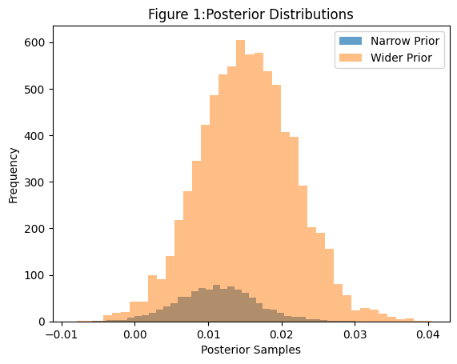

```python
import matplotlib.pyplot as plt

plt.hist(post_samples, bins=40, density=True, alpha=0.7, label='Narrow Prior')
plt.hist(post_wide, bins=40, alpha=0.5, label='Wider Prior')
plt.xlabel('Posterior Samples')
plt.ylabel('Frequency')
plt.title('Figure 1:Posterior Distributions')
plt.legend()
plt.savefig('posterior_distributions.png', dpi=300, bbox_inches='tight')  # Save the figure with high resolution
plt.show()
```

## Narrow vs. Wide Effects on Prior Beliefs

Under a tight prior $N(0, 0.01^2)$, the posterior mean is pulled towards the prior center at 0, and the credible interval is narrower, showing strong shrinkage towards the prior belief. With a much wider prior $N(0, 0.1^2)$, the posterior mean becomes more data-driven. The mean moves closer to the sample mean, and the posterior credible interval expands, indicating that the weaker prior information leads to greater uncertainty in the estimate of μ.